# Lab 6 - Multivariate Graphs

Data Visualization

Multivariate graphs display the relationships among three or more variables.

# Scatterplot matrix with `plot`

The native `plot` function does the job pretty well as long as you just need to display scatterplots.

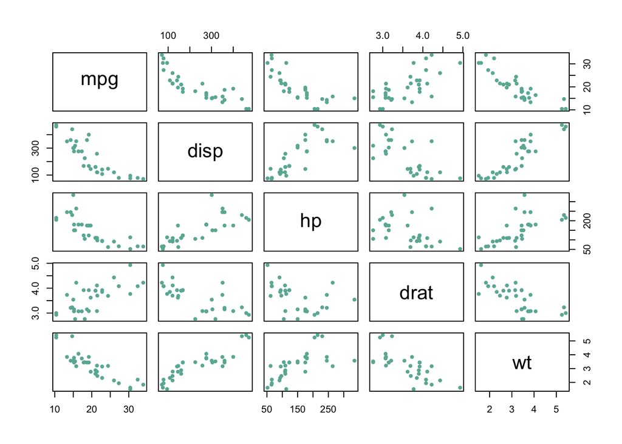

```r
# Data: numeric variables of the native mtcars dataset
data <- mtcars[ ,c(1, 3:6)]

# Plot
plot(data, pch=20, cex=1, col="#69b3a2")
```

```r
# ggpairs(data)
```

# Scatterplot matrix with `ggparis`

How to make Scatterplot Matrix using `ggpairs()`?

## Default scatterplot matrix

The `ggpairs()` function in the `GGally` package allows to build a great scatterplot matrix.

Scatterplots of each pair of numeric variable are drawn on the left part of the figure. Pearson correlation is displayed on the right. Variable distribution is available on the diagonal.

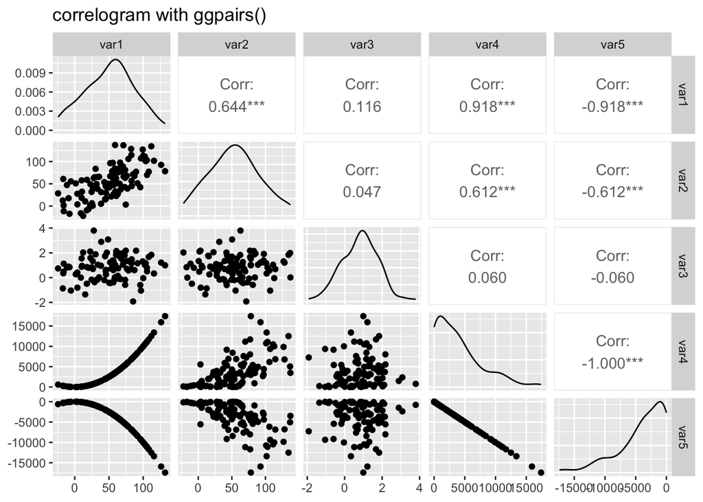

```r
library(GGally)

data <- data.frame( var1 = 1:100 + rnorm(100,sd=20),
                    var2 = 1:100 + rnorm(100,sd=27),
                    var3 = rep(1, 100) + rnorm(100, sd = 1))
data$var4 = data$var1 ** 2
data$var5 = -(data$var1 ** 2)

p <- ggpairs(data, title="correlogram with ggpairs()")
p
```

## Visualize correlation

The `ggcorr()` function allows to visualize the correlation of each pair of variable as a square. Note that the method argument allows to pick the correlation type you desire.

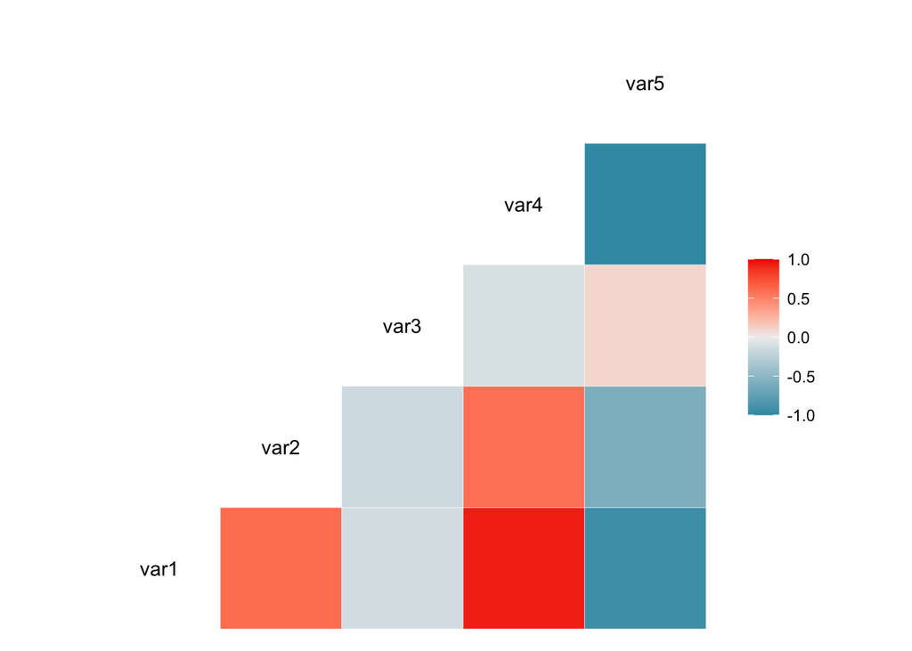

```r
library(GGally)

data <- data.frame( var1 = 1:100 + rnorm(100,sd=20),
                    var2 = 1:100 + rnorm(100,sd=27),
                    var3 = rep(1, 100) + rnorm(100, sd = 1))
data$var4 = data$var1 ** 2
data$var5 = -(data$var1 ** 2)

ggcorr(data)
```

## Split by group

It is possible to use ggplot2 aesthetics on the chart, for instance to color each category.

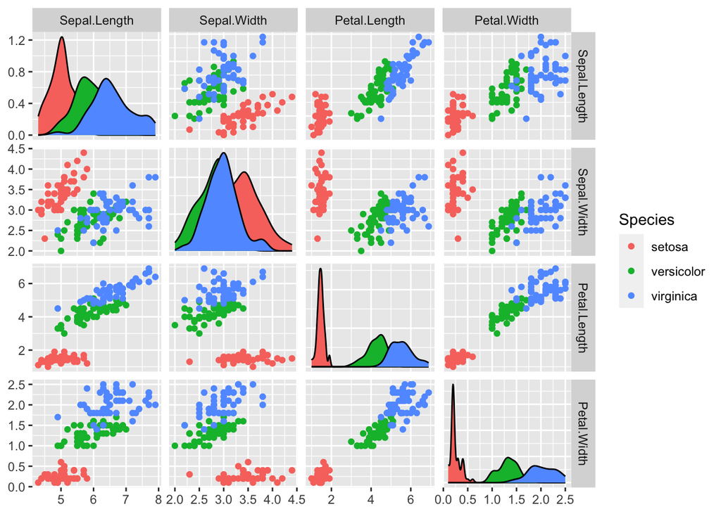

```r
library(GGally)
library(ggplot2)

ggpairs(iris,
        mapping = aes(col=Species),
        columns = 1:4,
        upper = list(continuous = "points"),
        legend = c(1,2),
        progress = F)
```

# Parallel coordinates

`ggally` is a `ggplot2` extension. It allows to build parallel coordinates charts thanks to the `ggparcoord()` function.

The input dataset must be a data frame with several numeric variables, each being used as a vertical axis on the chart. Columns number of these variables are specified in the columns argument of the function.

Note: here, a catergoric variable is used to color lines, as specified in the `groupColumn` variable.

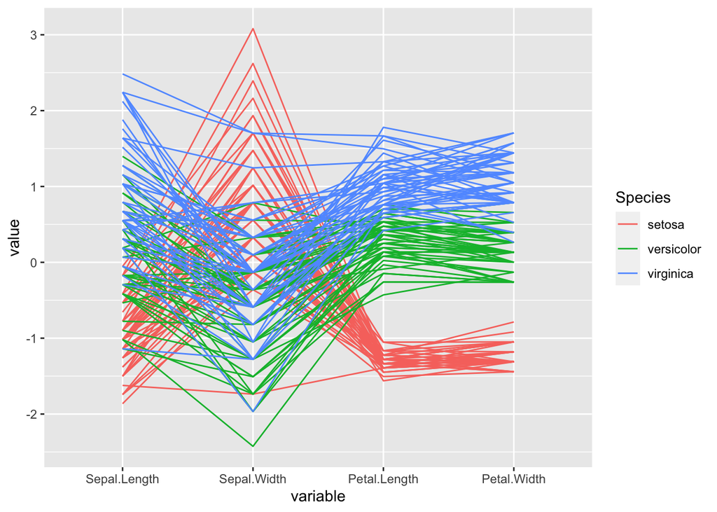

```r
# loading package
library(GGally)

# Data set is provided by R natively
data <- iris

# Plot
ggparcoord(data, columns = 1:4, groupColumn = 5)
```

## Custom color, theme, general appearance

This is pretty much the same chart as the previous one, except for the following customizations:

- color palette is improved thanks to the `viridis` package
- title is added with `title`
- dots are added with `showPoints`
- a bit of transparency is applied to lines with `alphaLines`

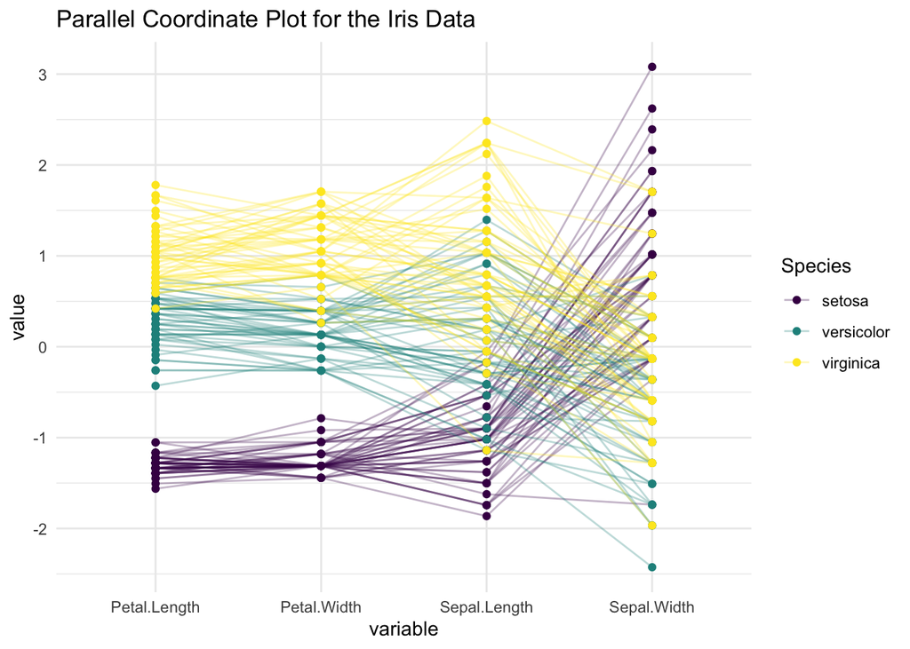

```r
# Loading packages
library(GGally)
library(viridis)

# Data set is provided by R natively
data <- iris

# Plot
ggparcoord(data,
           columns = 1:4,
           groupColumn = 5,
           order = "anyClass",
           showPoints = TRUE,
           title = "Parallel Coordinate Plot for the Iris Data",
           alphaLines = 0.3) +
  scale_color_viridis(discrete=TRUE) +
  theme_minimal()
```

## Highlight a group

Data visualization aims to highlight a story in the data. If you are interested in a specific group, you can highlight it as follow:

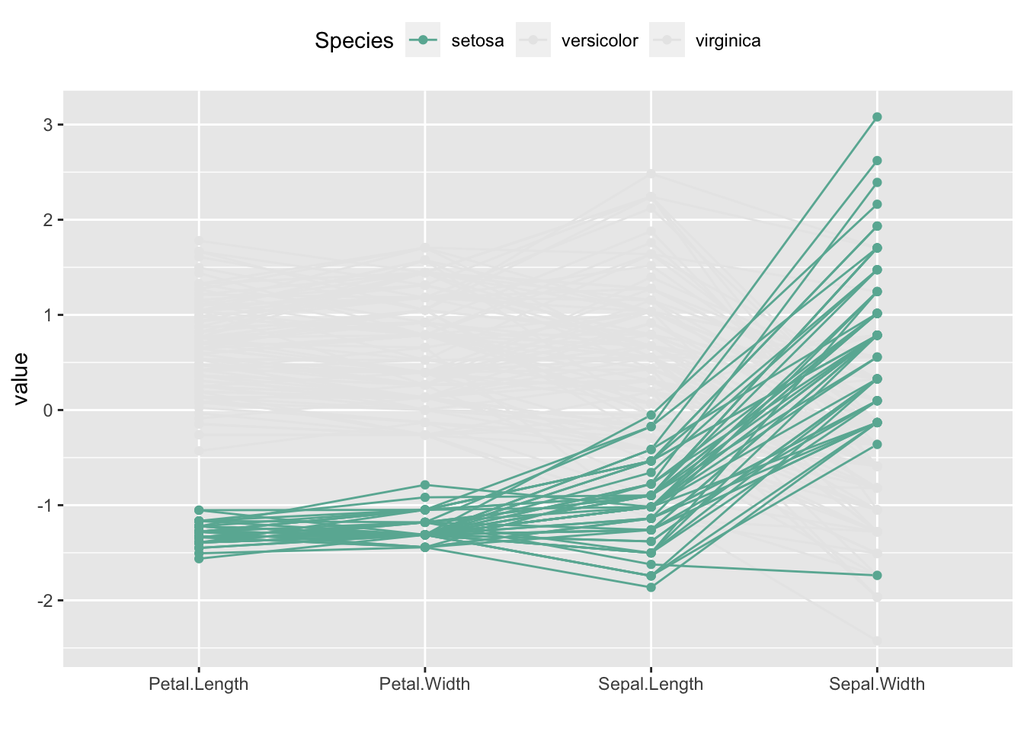

```r
# Libraries
library(GGally)
library(dplyr)

# Data set is provided by R natively
data <- iris

# Plot
data %>%
  arrange(desc(Species)) %>%
  ggparcoord(columns = 1:4,
             groupColumn = 5,
             order = "anyClass",
             showPoints = TRUE,
             title = "",
             alphaLines = 1) +
  scale_color_manual(values=c("#69b3a2", "#E8E8E8", "#E8E8E8")) +
  theme(legend.position="top",
        plot.title = element_text(size=10)) +
  xlab("")
```

# Select colors

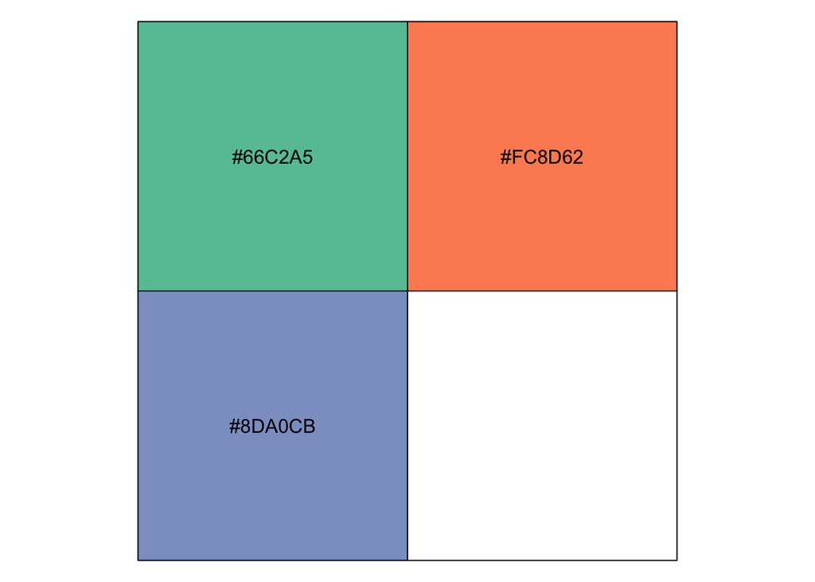

```r
library(scales)
mycolor1 <- brewer_pal(type = "seq", palette = "Set2")(nlevels(iris$Species))
mycolor2 <- viridis_pal()(9)
show_col(mycolor1)
```

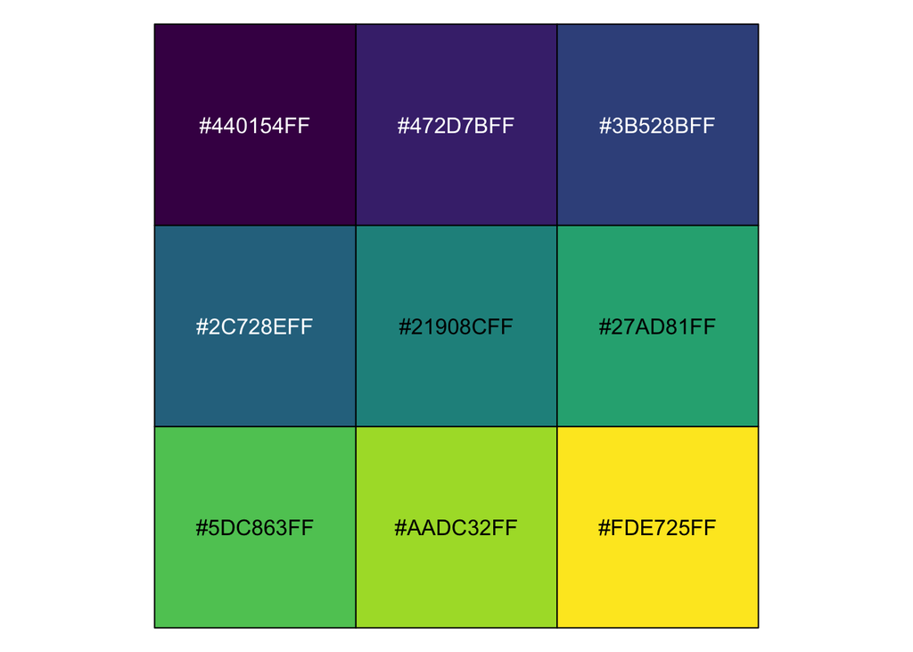

```r
show_col(viridis_pal()(9))
```

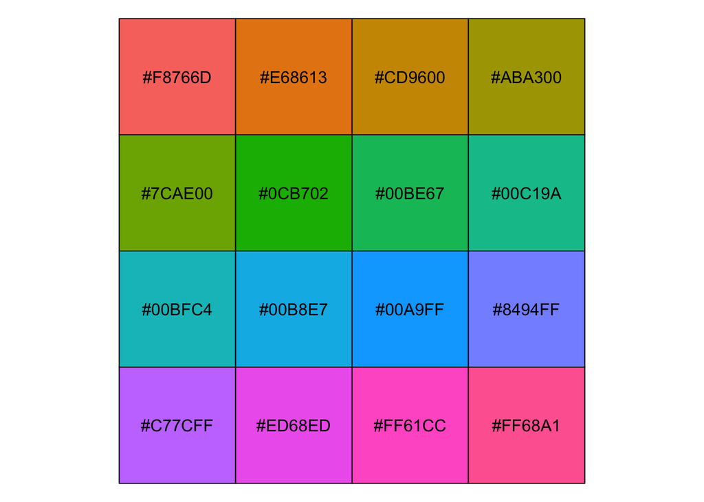

```r
show_col(hue_pal()(16))
```

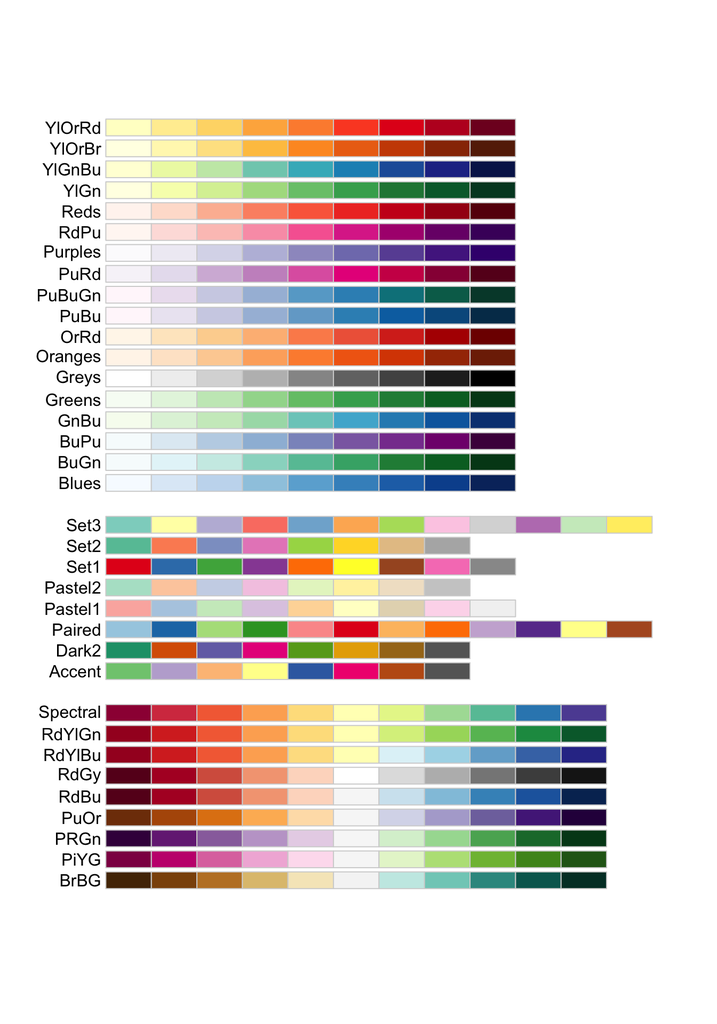

```r
library(RColorBrewer)
display.brewer.all()
```

**Reference**  
https://r-graph-gallery.com/